# Lab 3: Baseline Model — Simple Regression

- Show All Code
- Hide All Code
- View Source

CRISP-DM Phase 3 & 4 — Data Preparation & Modeling

Author

Prof. Dr. Jörg Schoder

Published

March 21, 2026

## 1 Learning Objectives and Overview

**NoteLearning Objectives**

- Understand simple linear regression as a **descriptive** tool: conditional means, not causal claims
- Read the regression equation as a **model formula** and interpret its coefficients correctly
- Compute and interpret the **coefficient of determination R²**
- Use **residuals** as a measure of underperformance and read the residual plot
- Diagnose **Omitted Variable Bias (OVB)** in the residual plot

**Scenario:** In Lab 2 you explored the Carseats data and established that `Price` is negatively correlated with `Sales`. Now you build the simplest possible regression model — the **baseline model** — and critically assess what it can and cannot do.

**TipSchedule**

⏱ **15 minutes** — Mandatory tasks (A1–A3), bonus tasks if time permits.

## 2 Background: Simple Linear Regression as a Descriptive Tool

### 2.1 What Is Simple Linear Regression — and What Is It Not?

Simple linear regression is often introduced alongside inferential machinery: standard errors, p-values, confidence intervals. Before we reach that machinery, it is worth stepping back and clarifying what regression *fundamentally is*.

**At its core, simple linear regression is a descriptive technique.**

Given a dataset of $n$ observations $(x_i, y_i)$, OLS finds the straight line that best summarises the relationship between $x$ and $y$ in that dataset. In our case: the line that best describes how average sales vary with price *across the 400 stores we have*.

This is important: the 400 Carseats stores are our **population** (or at least the complete dataset of interest). We are not trying to generalise from a small sample to a larger world — we are describing what is already in front of us. This is the same descriptive spirit as EDA in Lab 2.

### 2.2 Regression as Conditional Means

The OLS line can be understood as a machine for computing **conditional means**:

$$\hat{y}_i = \hat\beta_0 + \hat\beta_1 \cdot x_i \approx E[Y \mid X = x_i]$$

For each value of $x$ (price), the regression line gives the average $y$ (sales) across all stores with that price. The coefficients describe the *systematic* part of this relationship; residuals capture what is left over.

This perspective — regression as conditional means — makes coefficients intuitive:

- $\hat\beta_1$ is the **slope**: how much does the conditional mean of Sales change when Price increases by one unit?
- $\hat\beta_0$ is the **intercept**: what is the conditional mean of Sales when Price = 0? (Often not directly interpretable.)

### 2.3 A Note on the Standard Regression Table

When we estimate a regression on a **population** (all 400 stores), the standard output from `lm()` includes more columns than we strictly need right now:

| Column | Meaning | Relevant? |
| --- | --- | --- |
| `estimate` | The coefficient $\hat\beta$ | ✅ Yes — this is what we need |
| `std_error` | Standard error — how variable would $\hat\beta$ be across repeated samples? | ⚠️ Not meaningful for a population |
| `statistic` | t-value = estimate / std_error | ⚠️ Requires sampling context |
| `p_value` | Probability under $H_0: \beta = 0$ in a sampling framework | ⚠️ Not meaningful for a population |
| `lower_ci` / `upper_ci` | 95% confidence interval | ⚠️ Requires sampling context |

**ImportantDescriptive Context: What the Column Headers Actually Mean**

The column labelled `estimate` is somewhat misleading here: in a population analysis, $\hat\beta$ is not an **estimate** (which implies sampling uncertainty) but a **parameter** — the exact value of the slope for our 400 stores. Similarly, standard errors, p-values, and confidence intervals are concepts from sampling theory: they quantify how much results might vary across hypothetical repeated samples. When we treat the 400 stores as the population, there is no such variation — we have *all* the data.

**Practical consequence for this lab:**  
We focus exclusively on the `estimate` column. The other columns (standard error, t-value, p-value, confidence interval) are shown by the software, but they only become conceptually meaningful in PVA2, when we treat our data as a sample from a larger process and ask inferential questions.

### 2.4 The Model Formula

Before turning to R, let us write down the model we are going to fit and make explicit what its parts mean.

The **simple linear regression model** for our baseline case is:

$$\widehat{\text{Sales}}_i = \hat\beta_0 + \hat\beta_1 \cdot \text{Price}_i$$

**Interpretation of the coefficients:**

- $\hat\beta_1$ (slope): the **partial derivative** of $\widehat{\text{Sales}}$ with respect to $\text{Price}$:
  $$\hat\beta_1 = \frac{\partial \widehat{\text{Sales}}}{\partial \text{Price}}$$
  In plain language: for each additional dollar in price, the conditional mean of Sales changes by $\hat\beta_1$ thousand units — all else being equal (which here means: within the dataset as it is).
- $\hat\beta_0$ (intercept): the predicted value of $\widehat{\text{Sales}}$ when $\text{Price} = 0$. This is rarely interpretable in practice (no store charges zero), but it anchors the line.

**How are the coefficients chosen?**

OLS selects $\hat\beta_0$ and $\hat\beta_1$ to minimise the **sum of squared residuals (SSR)**:

$$\min_{\hat\beta_0,\, \hat\beta_1} \sum_{i=1}^{n} e_i^2 = \sum_{i=1}^{n}(y_i - \hat\beta_0 - \hat\beta_1 x_i)^2$$

Setting the first-order conditions (partial derivatives = 0) yields analytical solutions:

$$\hat\beta_1 = \frac{s_{xy}}{s_x^2} = \frac{\sum_i(x_i - \bar{x})(y_i - \bar{y})}{\sum_i(x_i - \bar{x})^2}$$

$$\hat\beta_0 = \bar{y} - \hat\beta_1 \cdot \bar{x}$$

Notice that $\hat\beta_1$ equals the correlation between $x$ and $y$, scaled by the ratio of their standard deviations:
$$\hat\beta_1 = r_{xy} \cdot \frac{s_y}{s_x}$$

This shows that the regression slope is directly linked to correlation — but expressed in the original units.

### 2.5 The Coefficient of Determination R²

The total variation in $y$ (TSS) can be decomposed into explained variation (ESS) and residual variation (SSR):

$$\underbrace{\sum_i(y_i - \bar{y})^2}_{\text{TSS}} = \underbrace{\sum_i(\hat{y}_i - \bar{y})^2}_{\text{ESS}} + \underbrace{\sum_i e_i^2}_{\text{SSR}}$$

The coefficient of determination measures the share of explained variation:

$$R^2 = \frac{\text{ESS}}{\text{TSS}} = 1 - \frac{\text{SSR}}{\text{TSS}} \in [0, 1]$$

**NoteInterpreting R² Correctly**

$R^2 = 0.15$ means: **15% of the variance in `Sales`** is explained by the model. The remaining 85% is attributable to other factors not in the model.

A low $R^2$ is **not a failure** — it signals that important variables are missing. Didactically, this is precisely the point: it motivates the **multiple model** with ShelveLoc and Advertising.

For simple regression, $R^2 = r_{xy}^2$ — the square of the Pearson correlation between $x$ and $y$.

**ImportantRegression as Benchmark — Not as Truth**

The regression line is **not** a causal model and **not** an exact prediction. It is a **market standard**: the sales a store *on average* should achieve at a given price.

A store with a strongly **negative residual** sells less than the price benchmark would predict — that is the underperformance signal we are looking for.

## 3 Step 1: Estimate the Baseline Model

### 3.1 The Model

Before running `lm()`, let us explicitly state what we are about to estimate:

$$\widehat{\text{Sales}}_i = \hat\beta_0 + \hat\beta_1 \cdot \text{Price}_i$$

We expect $\hat\beta_1 < 0$: stores that charge higher prices should, on average, sell fewer units. The EDA in Lab 2 confirmed this with $r \approx -0.44$.

### 3.2 Simple Regression: Sales ~ Price

```r
library(moderndive)

# Fit model
mod_baseline <- tbl_carseats %>%
  lm(Sales ~ Price, data = .)

# Regression table
mod_baseline %>%
  get_regression_table() %>%
  gt() %>%
  fmt_number(columns = c(estimate, std_error, statistic,
                         p_value, lower_ci, upper_ci),
             decimals = 4) %>%
  tab_style(
    style     = cell_fill(color = "#fff8e1"),
    locations = cells_body(rows = term == "Price")
  ) %>%
  tab_options(table.font.size = "14px") %>%
  tab_footnote("Yellow = slope coefficient for Price | Columns 2–6 relevant only in an inferential (sampling) context — see PVA2")
```

| term | estimate | std_error | statistic | p_value | lower_ci | upper_ci |
| --- | --- | --- | --- | --- | --- | --- |
| intercept | 13.6420 | 0.6330 | 21.5580 | 0.0000 | 12.3980 | 14.8860 |
| Price | −0.0530 | 0.0050 | −9.9120 | 0.0000 | −0.0640 | −0.0430 |

Yellow = slope coefficient for Price | Columns 2–6 relevant only in an inferential (sampling) context — see PVA2

**NoteReading the Regression Table — Today’s Focus**

| Column | Meaning | Today |
| --- | --- | --- |
| `estimate` | Coefficient $\hat\beta$ — the slope/intercept | ✅ Focus here |
| `std_error` | Standard error (sampling concept) | → PVA2 |
| `statistic` | t-value (sampling concept) | → PVA2 |
| `p_value` | p-value (sampling concept) | → PVA2 |
| `lower_ci` / `upper_ci` | Confidence interval (sampling concept) | → PVA2 |

Since we are working with a population (all 400 stores), the coefficients are **parameters**, not estimates. Standard errors, t-values, p-values and confidence intervals only become meaningful in PVA2 when we adopt a sampling perspective.

### 3.3 Model Quality

```r
mod_baseline %>%
  get_regression_summaries() %>%
  select(r_squared, adj_r_squared, rmse, sigma, nobs) %>%
  gt() %>%
  fmt_number(columns = c(r_squared, adj_r_squared, rmse, sigma),
             decimals = 4) %>%
  tab_options(table.font.size = "14px")
```

| r_squared | adj_r_squared | rmse | sigma | nobs |
| --- | --- | --- | --- | --- |
| 0.1980 | 0.1960 | 2.5260 | 2.5320 | 400 |

**Caution A1: Interpret the Coefficients**

Write out the regression equation and interpret the coefficients:

$$\widehat{\text{Sales}} = \hat\beta_0 + \hat\beta_1 \cdot \text{Price}$$

1. **Intercept $\hat\beta_0$:** What does this value mean in context? Is it sensibly interpretable (price = 0)?
2. **Slope $\hat\beta_1$:** How does the predicted sales change when the price increases by 1 USD? By 10 USD?
3. **$R^2$:** What percentage of the sales variance does the model explain? What does this say about the quality of the model?
4. **RMSE:** What does the Root Mean Squared Error tell us about the average prediction accuracy (in which units)?

### 3.4 Visualisation: The Regression Line

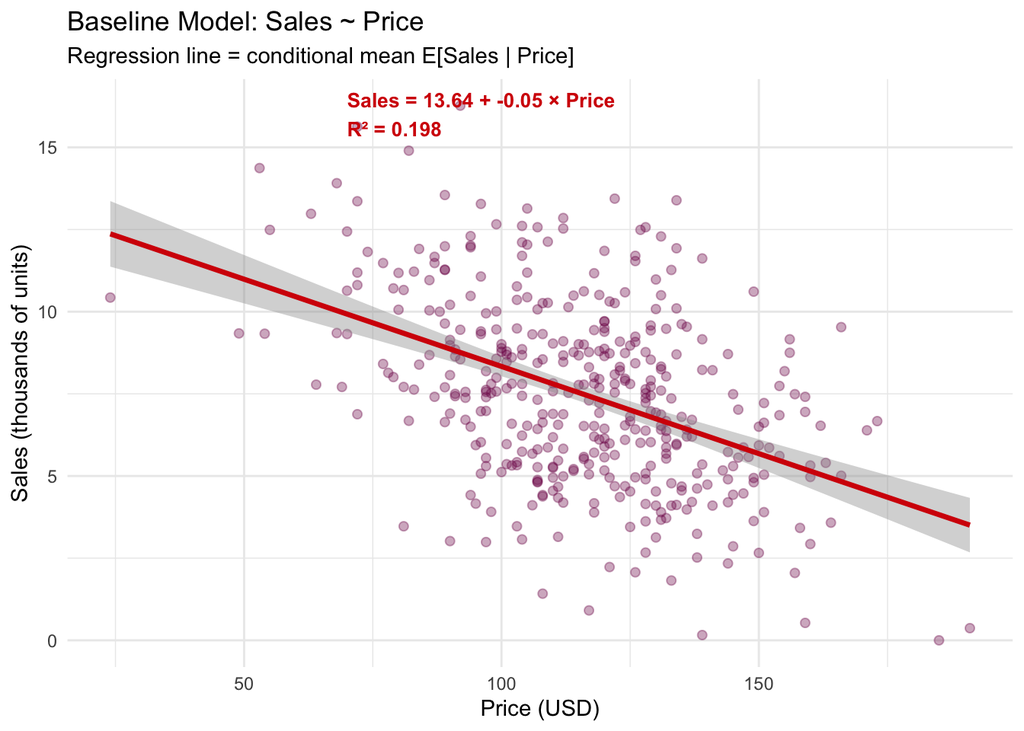

```r
tbl_carseats %>%
  ggplot(aes(x = Price, y = Sales)) +
  geom_point(alpha = 0.35, color = "#7d0a52", size = 1.8) +
  geom_smooth(method = "lm", color = "#D50006",
              se = TRUE, linewidth = 1.2) +
  annotate("text", x = 70, y = 16,
           label = paste0("Sales = ",
                          round(coef(mod_baseline)[1], 2), " + ",
                          round(coef(mod_baseline)[2], 2), " × Price\n",
                          "R² = ", round(summary(mod_baseline)$r.squared, 3)),
           color = "#D50006", size = 3.5, hjust = 0, fontface = "bold") +
  labs(
    title    = "Baseline Model: Sales ~ Price",
    subtitle = "Regression line = conditional mean E[Sales | Price]",
    x = "Price (USD)", y = "Sales (thousands of units)"
  ) +
  theme_minimal(base_size = 11)
```

## 4 Step 2: Residual Analysis

### 4.1 Compute and Display Residuals

```r
reg_points <- mod_baseline %>%
  get_regression_points()

# First 10 observations
reg_points %>%
  head(10) %>%
  gt() %>%
  fmt_number(columns = c(Sales, Price, Sales_hat, residual),
             decimals = 3) %>%
  tab_style(
    style     = cell_fill(color = "#fff0f0"),
    locations = cells_body(rows = residual < -2)
  ) %>%
  tab_style(
    style     = cell_fill(color = "#f0fff0"),
    locations = cells_body(rows = residual > 2)
  ) %>%
  tab_options(table.font.size = "13px") %>%
  tab_footnote("Red = strongly negative residual (underperformer) | Green = strongly positive (outperformer)")
```

| ID | Sales | Price | Sales_hat | residual |
| --- | --- | --- | --- | --- |
| 1 | 9.500 | 120.000 | 7.273 | 2.227 |
| 2 | 11.220 | 83.000 | 9.237 | 1.983 |
| 3 | 10.060 | 80.000 | 9.396 | 0.664 |
| 4 | 7.400 | 97.000 | 8.494 | −1.094 |
| 5 | 4.150 | 128.000 | 6.849 | −2.699 |
| 6 | 10.810 | 72.000 | 9.821 | 0.989 |
| 7 | 6.630 | 108.000 | 7.910 | −1.280 |
| 8 | 11.850 | 120.000 | 7.273 | 4.577 |
| 9 | 6.540 | 124.000 | 7.061 | −0.521 |
| 10 | 4.690 | 124.000 | 7.061 | −2.371 |

Red = strongly negative residual (underperformer) | Green = strongly positive (outperformer)

**NoteThe Residual as a Measure of Underperformance**

$$e_i = y_i - \hat{y}_i = \text{Sales}_i - \widehat{\text{Sales}}_i$$

- **$e_i < 0$:** Store sells **less** than the price benchmark predicts → underperformer
- **$e_i > 0$:** Store sells **more** than expected → outperformer
- **$e_i \approx 0$:** Store is at the market average

The residual quantifies the **deviation from the market standard** — this is the score for our performance mining (→ Lab 4).

### 4.2 Residual Plot

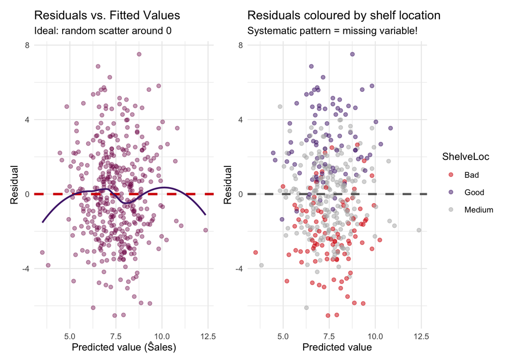

```r
pts <- augment(mod_baseline, data = tbl_carseats)

# Plot 1: Residuals vs. Fitted Values
p1 <- pts %>%
  ggplot(aes(x = .fitted, y = .resid)) +
  geom_point(alpha = 0.4, color = "#7d0a52", size = 1.5) +
  geom_hline(yintercept = 0, color = "#D50006",
             linewidth = 1.1, linetype = "dashed") +
  geom_smooth(method = "loess", color = "#502479",
              se = FALSE, linewidth = 0.8) +
  labs(title = "Residuals vs. Fitted Values",
       subtitle = "Ideal: random scatter around 0",
       x = "Predicted value (Ŝales)", y = "Residual") +
  theme_minimal(base_size = 10)

# Plot 2: Residuals coloured by ShelveLoc
p2 <- pts %>%
  ggplot(aes(x = .fitted, y = .resid, color = ShelveLoc)) +
  geom_point(alpha = 0.5, size = 1.5) +
  geom_hline(yintercept = 0, color = "#686868",
             linewidth = 1, linetype = "dashed") +
  scale_color_manual(values = c("Bad"    = "#D50006",
                                "Medium" = "#b3b2b2",
                                "Good"   = "#502479")) +
  labs(title = "Residuals coloured by shelf location",
       subtitle = "Systematic pattern = missing variable!",
       x = "Predicted value", y = "Residual",
       color = "ShelveLoc") +
  theme_minimal(base_size = 10)

p1 + p2
```

**Caution A2: Interpret the Residual Plot**

1. **Left plot:** Does the residual plot show a random pattern or a systematic structure? What would an ideal residual plot look like?
2. **Right plot:** Describe the pattern after colouring by ShelveLoc.
   - Where do the red points (Bad) tend to cluster?
   - Where do the purple points (Good) cluster?
   - What does this tell us about a missing variable in the model?
3. **Omitted Variable Bias:** If a confounder (ShelveLoc) correlates with both the regressor (Price) and the target variable (Sales) — in which direction is the price coefficient biased?

```r
# Check: Does ShelveLoc correlate with Price?
tbl_carseats %>%
  group_by(ShelveLoc) %>%
  summarise(mean_price = mean(Price),
            mean_sales = mean(Sales))
```

## 5 Step 3: OVB Diagnosis and Log Transformation

### 5.1 Compute R² Manually

```r
ssq <- reg_points %>%
  summarise(
    TSS = sum((Sales - mean(Sales))^2),
    SSR = sum(residual^2),
    ESS = TSS - SSR,
    R2  = 1 - SSR / TSS
  )
ssq %>%
  gt() %>%
  fmt_number(columns = everything(), decimals = 2) %>%
  tab_options(table.font.size = "14px")
```

| TSS | SSR | ESS | R2 |
| --- | --- | --- | --- |
| 3,182.27 | 2,552.23 | 630.05 | 0.20 |

### 5.2 Comparison: Linear vs. Log-Linear Model

The log-linear model modifies the specification as follows:

$$\ln(\widehat{\text{Sales}}_i) = \hat\beta_0 + \hat\beta_1 \cdot \text{Price}_i$$

Here $\hat\beta_1$ is no longer a unit change in Sales per unit of Price, but an approximate **percentage change** in Sales per unit of Price:

$$\hat\beta_1 \approx \frac{\Delta \text{Sales\%}}{1 \text{ USD price increase}}$$

```r
# Model with log(Sales)
tbl_carseats_log <- tbl_carseats %>%
                      filter(Sales > 0) %>%   # log(0) is undefined
                      mutate(log_sales = log(Sales))

mod_log <- tbl_carseats_log %>%
  lm(log_sales ~ Price, data = .)

# Comparison
tibble(
  Model    = c("Sales ~ Price (linear)", "log(Sales) ~ Price (log-linear)"),
  R2       = c(summary(mod_baseline)$r.squared,
               summary(mod_log)$r.squared),
  `β_Price` = c(coef(mod_baseline)[2],
                coef(mod_log)[2]),
  Interpretation = c(
    "1 USD more → β̂ thousand units more Sales",
    "1 USD more → β̂ × 100% more log(Sales) ≈ % change in Sales"
  )
) %>%
  gt() %>%
  fmt_number(columns = c(R2, `β_Price`), decimals = 4) %>%
  tab_options(table.font.size = "13px")
```

| Model | R2 | β_Price | Interpretation |
| --- | --- | --- | --- |
| Sales ~ Price (linear) | 0.1980 | −0.0531 | 1 USD more → β̂ thousand units more Sales |
| log(Sales) ~ Price (log-linear) | 0.1599 | −0.0084 | 1 USD more → β̂ × 100% more log(Sales) ≈ % change in Sales |

**NoteInterpretation of the Log-Linear Coefficient**

In the log-linear model, for small $\hat\beta$:

$$\hat\beta_1 \approx \frac{\Delta \text{Sales\%}}{1 \text{ USD price}}$$

Exactly: $e^{\hat\beta_1} - 1 =$ percentage change in Sales per 1 USD price increase.

```r
# Exact percentage change
(exp(coef(mod_log)[2]) - 1) * 100
```

**Caution A3: Model Comparison and OVB**

1. Compare $R^2$ of both models. Does the log transformation improve model fit?
2. **OVB formula:** The bias in the price coefficient can be written as:
   $$\hat\beta_{\text{Price, biased}} = \beta_{\text{Price}} + \underbrace{\beta_{\text{ShelveLoc}} \cdot \frac{\text{Cov(Price, ShelveLoc)}}{\text{Var(Price)}}}_{\text{Bias}}$$

   Check empirically: how much does $\hat\beta_{\text{Price}}$ change when ShelveLoc is added to the model?

```r
# Model WITHOUT ShelveLoc
mod_without <- lm(Sales ~ Price, data = tbl_carseats)

# Model WITH ShelveLoc
mod_with    <- lm(Sales ~ Price + ShelveLoc, data = tbl_carseats)

# Compare price coefficients
coef(mod_without)["Price"]
coef(mod_with)["Price"]
```

3. In which direction is the coefficient biased? Is this consistent with your expectation from A2?

## 6 Bonus Tasks

**Tip B1: Visualise the Variance Decomposition**

Visualise TSS, ESS, and SSR for the first 20 observations:

```r
first20 <- reg_points %>% slice(1:20) %>%
  mutate(
    ybar   = mean(tbl_carseats$Sales),
    x_rank = row_number()
  )

ggplot(first20, aes(x = x_rank)) +
  # TSS: deviation from the mean
  geom_segment(aes(xend = x_rank, y = ybar, yend = Sales),
               color = "#b3b2b2", linewidth = 1) +
  # SSR: residuals
  geom_segment(aes(xend = x_rank, y = Sales_hat, yend = Sales),
               color = "#D50006", linewidth = 1.2) +
  # ESS: explained deviation
  geom_segment(aes(xend = x_rank, y = ybar, yend = Sales_hat),
               color = "#502479", linewidth = 1.2) +
  geom_point(aes(y = Sales), color = "#7d0a52", size = 2) +
  geom_point(aes(y = Sales_hat), color = "#D50006", shape = 17, size = 2) +
  geom_hline(yintercept = mean(tbl_carseats$Sales),
             linetype = "dashed", color = "#686868") +
  labs(title = "Variance decomposition: TSS = ESS + SSR",
       subtitle = "Grey = TSS | Purple = ESS (explained) | Red = SSR (residual)",
       x = "Observation", y = "Sales") +
  theme_minimal()
```

**Tip B2: Coefficient of Determination and Correlation**

Show empirically that in the case of simple regression:
$$R^2 = r_{x,y}^2$$

```r
r_xy <- cor(tbl_carseats$Price, tbl_carseats$Sales)
r_xy^2
summary(mod_baseline)$r.squared
```

Why does this equality hold **only** for simple regression, not for multiple regression?

**Tip B3: Identify Underperformers**

Create a first ranking of underperforming stores based on the baseline model:

```r
reg_points %>%
  arrange(residual) %>%
  head(10) %>%
  select(ID, Sales, Price, Sales_hat, residual) %>%
  gt() %>%
  fmt_number(columns = c(Sales, Sales_hat, residual), decimals = 2) %>%
  tab_style(
    style = cell_fill(color = "#fff0f0"),
    locations = cells_body(rows = residual < -3)
  )
```

What do the top underperformers have in common? Look at their ShelveLoc category.

## 7 Summary

| Criterion | Baseline (Sales ~ Price) | Expected with ShelveLoc |
| --- | --- | --- |
| R² | 0.198 | ~0.50 (substantially better) |
| β_Price | -0.053 USD/thousand | Changes due to OVB correction |
| Residual plot | Systematic pattern (ShelveLoc) | Random scatter around 0 |
| Usability | Too inaccurate for decisions | Better benchmark quality |
| Main problem | Omitted Variable Bias via ShelveLoc | Resolved by multiple regression |

**ImportantKey Messages of This Lab**

1. **Regression = conditional mean** — not a causal model, but a benchmark.
2. **Descriptive perspective:** Since all 400 stores form our population, the coefficients are **parameters** (not estimates). Standard errors, p-values, and confidence intervals shown by R require a sampling context and become relevant in PVA2.
3. **R² = 0.2** — price alone explains only a small share of sales variance. This is not a flaw — it is a signal that important variables are missing.
4. **The residual plot diagnoses OVB** — the systematic ShelveLoc pattern shows that the price coefficient is biased by a missing variable.
5. **Log transformation** improves model assumptions for right-skewed outcomes and makes coefficients interpretable as (approximate) elasticities.

**NoteTransition to the Live Demo**

This is the **multiple regression model** — and it leads directly to Lab 4: Performance Mining.